# Final

## Introduction

This notebook focuses on collecting, processing, interpreting, and making predictions on housing data. With the noticeable and problematic increase in housing prices, including buyers and renters, this notebook aims to fully understand the difference between the median income and the average housing prices.

### Factors To Address

There are many factors to consider when looking at the differences between income and the median sale price of houses listed on Zillow. While the affects of inflation do impact both the housing market and median income data, it can make the difference between the two seem larger than the actual value.

Another factor to address is the difference in median income and housing prices per location. These two values are going to vary and may be more or less favorable depending on how the two values are effected. In this analysis, the data as a whole is going to be analyzed, meaning that the average between all locations main focus with the specific locations being less prioritized.

### Impact Of This Analysis

Learning more about the relationship between the median housing price and income is important for learning the true danger that the drastic increase in housing prices can cause. It helps shed light on the problems with accessibility to housing that is currently happening and that is continuing to grow. This can help inform those who can regulate these prices and help aid the issue by providing an accurate analysis of the data. For those who are looking to buy or sell a home, there is also the added benefit of understanding the differences between income and housing price by location. With different regions changing at different rates, it might help guide people to choosing a smart location to live and purchase any sort of housing.

Created By: Jonathan Evan Henkle UID: 118954202

```python
import pandas as pd
import numpy as np
import matplotlib.pyplot as plt
import seaborn as sns
from statsmodels.tsa.seasonal import seasonal_decompose
from sklearn.linear_model import LinearRegression
from sklearn.metrics import mean_squared_error
```

## Median Sale Price

This data downloaded from Zillow's housing price database is the median income of all house types. This is the raw data, unprocessed by Zillow beforehand. This data is sporadic and highly effected by seasonal changes and inflation. From there we can remove the unnecessary data, clean up the datapoints, and format it to make it easy to graph and manipulate. This is the main data that we will be processing and analyzing.

```python
median_path = 'Final/median_sale_price.csv' # file path
median_df = pd.read_csv(median_path) # turning csv of median sale price dataninto pandas dataframe

# removing the unneccesary columns from the dataframe
median_df.drop(["SizeRank", "RegionType", "RegionID", "StateName"], axis=1, inplace=True)
# removes any locations with incomplete data
median_df.dropna(axis=0, inplace=True)
# moves the index to the region name
median_df.set_index("RegionName", inplace=True)
# converts the date (currently strings) into datetime objects and updates columns
new_columns = pd.to_datetime(median_df.columns)
median_df.columns = new_columns
# transposes date to have each columns be the complete data of a different location
median_df = median_df.T
median_df.head(6)
```

| RegionName | United States | Los Angeles, CA | Chicago, IL | Dallas, TX | Washington, DC | Philadelphia, PA | Miami, FL | Atlanta, GA | Boston, MA | Phoenix, AZ | ... | Gardnerville Ranchos, NV | Ca-¦on City, CO | Bardstown, KY | Hillsdale, MI | Lawrenceburg, TN | McMinnville, TN | Dyersburg, TN | Kill Devil Hills, NC | Lewisburg, TN | Breckenridge, CO |
| --- | --- | --- | --- | --- | --- | --- | --- | --- | --- | --- | --- | --- | --- | --- | --- | --- | --- | --- | --- | --- | --- |
| 2008-02-29 | 172500.0 | 470000.0 | 218000.0 | 138000.0 | 338000.0 | 191000.0 | 239000.0 | 150000.0 | 300000.0 | 215000.0 | ... | 330000.0 | 114900.0 | 93250.0 | 89750.0 | 73250.0 | 63500.0 | 75000.0 | 297500.0 | 85850.0 | 395000.0 |
| 2008-03-31 | 177500.0 | 455000.0 | 221575.0 | 145900.0 | 327250.0 | 198900.0 | 235000.0 | 154500.0 | 310000.0 | 212000.0 | ... | 285000.0 | 104750.0 | 96500.0 | 82200.0 | 69419.0 | 65000.0 | 74900.0 | 305000.0 | 107844.0 | 454000.0 |
| 2008-04-30 | 179000.0 | 458000.0 | 221796.0 | 144900.0 | 330000.0 | 200000.0 | 238000.0 | 154700.0 | 315000.0 | 210000.0 | ... | 348000.0 | 130000.0 | 89900.0 | 62900.0 | 57000.0 | 64750.0 | 67500.0 | 320000.0 | 101267.0 | 445000.0 |
| 2008-05-31 | 180000.0 | 440000.0 | 228000.0 | 150000.0 | 335000.0 | 212000.0 | 232000.0 | 158950.0 | 333000.0 | 205000.0 | ... | 281250.0 | 128000.0 | 104000.0 | 75550.0 | 58750.0 | 72500.0 | 73500.0 | 325000.0 | 85000.0 | 420000.0 |
| 2008-06-30 | 185000.0 | 435000.0 | 235000.0 | 155500.0 | 335000.0 | 218000.0 | 237600.0 | 158800.0 | 345000.0 | 199000.0 | ... | 264000.0 | 129700.0 | 117450.0 | 70000.0 | 78500.0 | 62300.0 | 62925.0 | 308500.0 | 80000.0 | 448700.0 |
| 2008-07-31 | 184000.0 | 420000.0 | 235000.0 | 154000.0 | 327700.0 | 223950.0 | 227000.0 | 154000.0 | 339000.0 | 184950.0 | ... | 316500.0 | 149400.0 | 100000.0 | 69750.0 | 66000.0 | 64250.0 | 76000.0 | 342000.0 | 88500.0 | 360000.0 |

6 rows × 440 columns

## Mean Sale Price

Data also collected from Zillow's database. This is being process and manipulated in the same manner as the median dataset. The primary purpose of these is to compare the mean vs median datasets. In general, mean data is affected more by outliers compared to the median, so for this analysis we will be focusing on the median.

```python
# importing the dataframe
mean_path = 'Final/mean_sale_price.csv'
mean_df = pd.read_csv(mean_path)

# removing the unnecessary columns and switching the indexes through the same process as the median_df
mean_df.drop(["SizeRank", "RegionType", "RegionID", "StateName"], axis=1, inplace=True)
mean_df.dropna(axis=0, inplace=True)
mean_df.set_index("RegionName", inplace=True)
new_columns = pd.to_datetime(mean_df.columns)
new_columns = new_columns
mean_df.columns = new_columns
mean_df = mean_df.T
mean_df.head(6)
```

| RegionName | United States | Los Angeles, CA | Chicago, IL | Dallas, TX | Houston, TX | Washington, DC | Philadelphia, PA | Miami, FL | Atlanta, GA | Boston, MA | ... | Bartlesville, OK | Galesburg, IL | Pahrump, NV | Newport, OR | Shelbyville, TN | Gardnerville Ranchos, NV | Ca-¦on City, CO | Hillsdale, MI | Dyersburg, TN | Breckenridge, CO |
| --- | --- | --- | --- | --- | --- | --- | --- | --- | --- | --- | --- | --- | --- | --- | --- | --- | --- | --- | --- | --- | --- |
| 2008-02-29 | 250192.0 | 623109.0 | 285566.0 | 190893.0 | 198172.0 | 399584.0 | 230341.0 | 343855.0 | 199700.0 | 383649.0 | ... | 97901.0 | 88904.0 | 187412.0 | 384556.0 | 104909.0 | 530735.0 | 115135.0 | 101859.0 | 79014.0 | 503037.0 |
| 2008-03-31 | 252961.0 | 612490.0 | 284936.0 | 195202.0 | 200112.0 | 393915.0 | 229562.0 | 340144.0 | 201576.0 | 408334.0 | ... | 95254.0 | 76006.0 | 159083.0 | 328024.0 | 87034.0 | 422519.0 | 122950.0 | 93999.0 | 89890.0 | 595834.0 |
| 2008-04-30 | 256078.0 | 613320.0 | 278755.0 | 199415.0 | 199737.0 | 396307.0 | 232891.0 | 339880.0 | 201636.0 | 414374.0 | ... | 124729.0 | 102538.0 | 139348.0 | 295746.0 | 113637.0 | 406164.0 | 162638.0 | 83202.0 | 120471.0 | 597857.0 |
| 2008-05-31 | 256796.0 | 579251.0 | 284091.0 | 209542.0 | 215326.0 | 399899.0 | 243371.0 | 358571.0 | 206989.0 | 420852.0 | ... | 121279.0 | 108720.0 | 200395.0 | 343654.0 | 126694.0 | 332284.0 | 140271.0 | 85164.0 | 82382.0 | 545968.0 |
| 2008-06-30 | 262253.0 | 582954.0 | 295515.0 | 205878.0 | 224633.0 | 405785.0 | 256627.0 | 352963.0 | 208386.0 | 432040.0 | ... | 120312.0 | 74255.0 | 189397.0 | 347799.0 | 125602.0 | 358157.0 | 151081.0 | 90201.0 | 83008.0 | 595233.0 |
| 2008-07-31 | 260888.0 | 554571.0 | 295485.0 | 206834.0 | 213316.0 | 399379.0 | 263225.0 | 334778.0 | 201137.0 | 426769.0 | ... | 102782.0 | 92737.0 | 178110.0 | 243222.0 | 101065.0 | 402071.0 | 154390.0 | 94816.0 | 97839.0 | 524825.0 |

6 rows × 396 columns

## Income Dataset

In order to highlight the purpose of this analysis, comparing the rising house prices to median income data can help showcase the difference in house increases compared to the increase in income. This data is being turned into a pandas dataframe with datetime objects as the index and the income data in the "Income" column.

```python
# import of median income dataset as dataframe
income_path = "Final/income_data.csv"
income_df = pd.read_csv(income_path)

# manipulating the dataframe so it is listed as a single column with datetime objects as row indices
income_df.columns = ["Date", "Income"]
income_df.index = pd.to_datetime(income_df["Date"])
income_df.drop(["Date"], axis=1, inplace=True)
income_df = income_df[income_df.index.year >= 2008] # constricting timeframe to match with Zillow data
income_df
```

| Date | Income |
| --- | --- |
| 2008-01-01 | 66280 |
| 2009-01-01 | 65850 |
| 2010-01-01 | 64300 |
| 2011-01-01 | 63350 |
| 2012-01-01 | 63350 |
| 2013-01-01 | 65740 |
| 2014-01-01 | 64900 |
| 2015-01-01 | 68410 |
| 2016-01-01 | 70840 |
| 2017-01-01 | 72090 |
| 2018-01-01 | 73030 |
| 2019-01-01 | 78250 |
| 2020-01-01 | 76660 |
| 2021-01-01 | 76330 |
| 2022-01-01 | 74580 |

## Adjusting For Inflation

Using the United States monthly inflation data, we can calculate annual inflation rate using the monthly rate. This can be applied to scale the dataset and create a rate of housing price increase that is unaffected by inflation.

```python
# function to turn monthly data into annual inflation data
def calculate_annual_inflation(row):
    # converting the percentage data to decimal data
    monthly_rates_decimal = [1 + (rate / 100) for rate in row]
    # creating the product
    annual_rate = np.prod(monthly_rates_decimal)
    # converts the inflation rate from decimal back to percentage
    annual_inflation_rate = (annual_rate - 1) * 100
    return annual_inflation_rate

# importing inflation data
inflation_path = "Final/inflation_data.csv"
inflation_df = pd.read_csv(inflation_path)

# removing unnecessary columns and adding columns to create annual data
inflation_df.drop(["HALF1", "HALF2"], axis=1, inplace=True)
inflation_df["Annual"] = inflation_df.iloc[:, 1:].apply(calculate_annual_inflation, axis=1)

# creating a value to scale the years of the median and income dataframe by centered around 2008
# this means the actual dollar value is in terms of 2008 data
inflation_df['CumulativeInflation'] = (1 + inflation_df['Annual'] / 100).cumprod()
base_year = 2008
base_cpi = inflation_df[inflation_df['Year'] == base_year]['CumulativeInflation'].values[0]
inflation_df['CumulativeInflation'] /= base_cpi
inflation_df.head()
```

|  | Year | Jan | Feb | Mar | Apr | May | Jun | Jul | Aug | Sep | Oct | Nov | Dec | Annual | CumulativeInflation |
| --- | --- | --- | --- | --- | --- | --- | --- | --- | --- | --- | --- | --- | --- | --- | --- |
| 0 | 1984 | 0.7 | 0.5 | 0.3 | 0.4 | 0.2 | 0.2 | 0.4 | 0.3 | 0.3 | 0.4 | 0.2 | 0.2 | 4.176642 | 0.500015 |
| 1 | 1985 | 0.2 | 0.6 | 0.5 | 0.2 | 0.2 | 0.3 | 0.2 | 0.2 | 0.2 | 0.4 | 0.5 | 0.5 | 4.072776 | 0.520379 |
| 2 | 1986 | 0.4 | -0.2 | -0.5 | -0.4 | 0.3 | 0.4 | 0.1 | 0.1 | 0.4 | 0.2 | 0.2 | 0.4 | 1.403359 | 0.527682 |
| 3 | 1987 | 0.5 | 0.4 | 0.4 | 0.4 | 0.3 | 0.4 | 0.3 | 0.4 | 0.3 | 0.3 | 0.3 | 0.2 | 4.281438 | 0.550274 |
| 4 | 1988 | 0.3 | 0.2 | 0.3 | 0.6 | 0.3 | 0.4 | 0.4 | 0.4 | 0.4 | 0.3 | 0.3 | 0.3 | 4.281232 | 0.573833 |

## Before Adjusting

Before adjusting for inflation, we can get an idea of what these different graphs will look like by location compared to the income data and how the shape of different locations can change. This will provide a baseline to give a glimpse at the data were working with and to look at later when further modifications have been made.

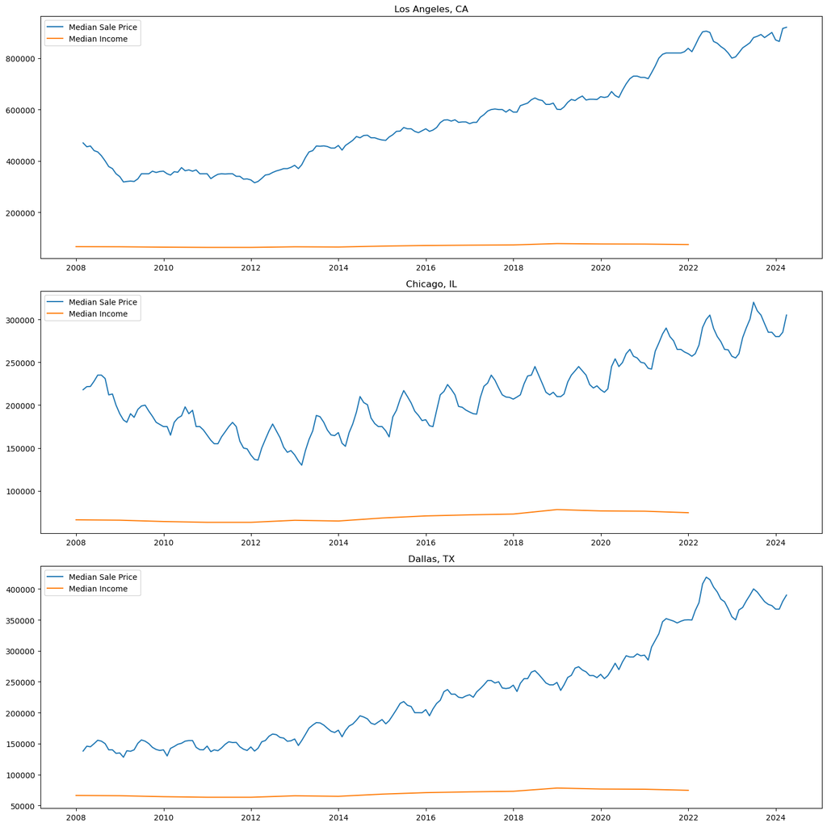

```python
# setting up plot variables
nrows = 3 # number of rows in plot
ncols = 1 # number of columns in the plot
total_plots = nrows * ncols # total number of rows in the plot
fig, axes = plt.subplots(nrows=nrows, ncols=ncols, figsize=(15, 15)) # subplots

# creating the predefined x_values for the data so they match up
x_values = median_df.index
income_x_values = income_df.index

# plots the median sale price for different locations
for i, col in enumerate(median_df.columns[1:total_plots + 1]):
    if nrows == 1 or ncols == 1:
        ax = axes[i]
    else:
        ax = axes[i // ncols, i % ncols]

    # plot median data for the current location
    ax.plot(x_values, median_df[col], label='Median Sale Price')

    # plots the income data with the income x values
    ax.plot(income_x_values, income_df["Income"].values, label='Median Income')

    # Dds the title and legend
    ax.set_title(col)
    ax.legend()

plt.tight_layout()
plt.show()
```

## Comparing Mean vs Median

We can use this opportunity to compare the mean and median datasets as well. The applications of both are going to be very similar, so it might make sense to only use one if the graphs are similar. In this case they very much are with no signficant outliers skewing the mean very far. With this in mind, we can move forward with our notebook working with the median dataset.

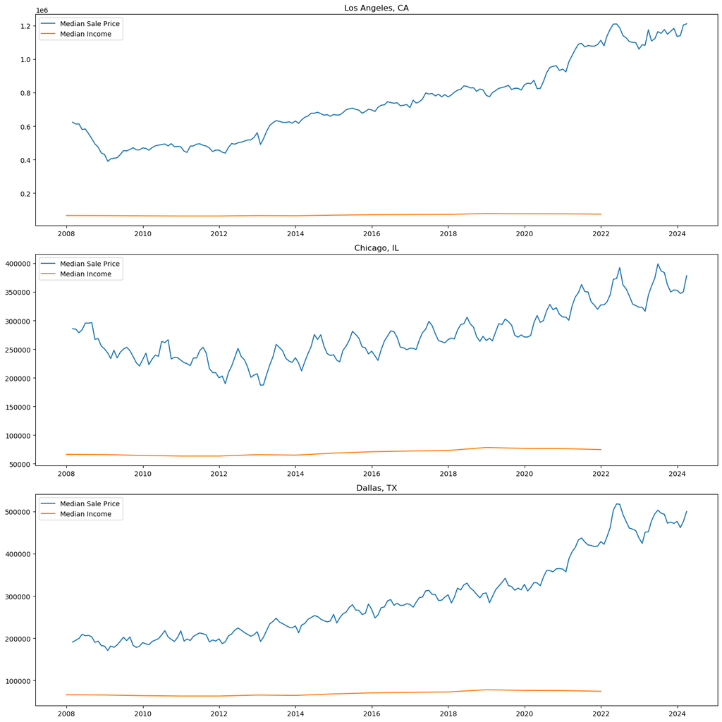

```python
nrows = 3 # number of rows in plot
ncols = 1 # number of columns in the plot
total_plots = nrows * ncols # total number of rows in the plot
fig, axes = plt.subplots(nrows=nrows, ncols=ncols, figsize=(15, 15)) # subplots

# creating the predefined x_values for the data so they match up
x_values = mean_df.index
income_x_values = income_df.index

# plots the median sale price for different locations
for i, col in enumerate(mean_df.columns[1:total_plots + 1]):
    if nrows == 1 or ncols == 1:
        ax = axes[i]
    else:
        ax = axes[i // ncols, i % ncols]

    # plot median data for the current location
    ax.plot(x_values, mean_df[col], label='Median Sale Price')

    # plots the income data with the income x values
    ax.plot(income_x_values, income_df["Income"].values, label='Median Income')

    # adds the title and legend
    ax.set_title(col)
    ax.legend()

plt.tight_layout()
plt.show()
```

## Inflation Adjustment

```python
# creating copies to have normailized dataframes seperate but will use exclusively
normalized_mean_df = mean_df.copy()
normalized_median_df = median_df.copy()
normalized_income_df = income_df.copy()

# index of inflation data by year
cumulative_inflation_dict = inflation_df.set_index('Year')['CumulativeInflation'].to_dict()

# although not used, we will normalized the mean_df incase we ever want to work with mean data in future
for index in mean_df.index:
    # removing uncessary columns
    for col in mean_df.columns[2:]:
        # gets the year from the column
        if isinstance(col, pd.Timestamp):
            year = col.year
            # normalizes value based on current year
            normalized_mean_df.at[index, col] = mean_df.at[index, col] / cumulative_inflation_dict[year]

# same process for median dataframe
for index in median_df.index:
    for col in median_df.columns[2:]:
        if isinstance(col, pd.Timestamp):
            year = col.year
            # normalize values based on year
            normalized_median_df.at[index, col] = median_df.at[index, col] / cumulative_inflation_dict[year]

# finally we can normalize the income as well
for col in income_df.columns:
    # gets year for data point
    if isinstance(col, pd.Timestamp):
        year = col.year
        # updates value based on year
        normalized_income_df[col] = income_df[col] / cumulative_inflation_dict[year]

# updating useful dataframes to keep variable names consistent
median_df = normalized_median_df
income_df = normalized_income_df
```

## Comparison After Inflation Adjustment

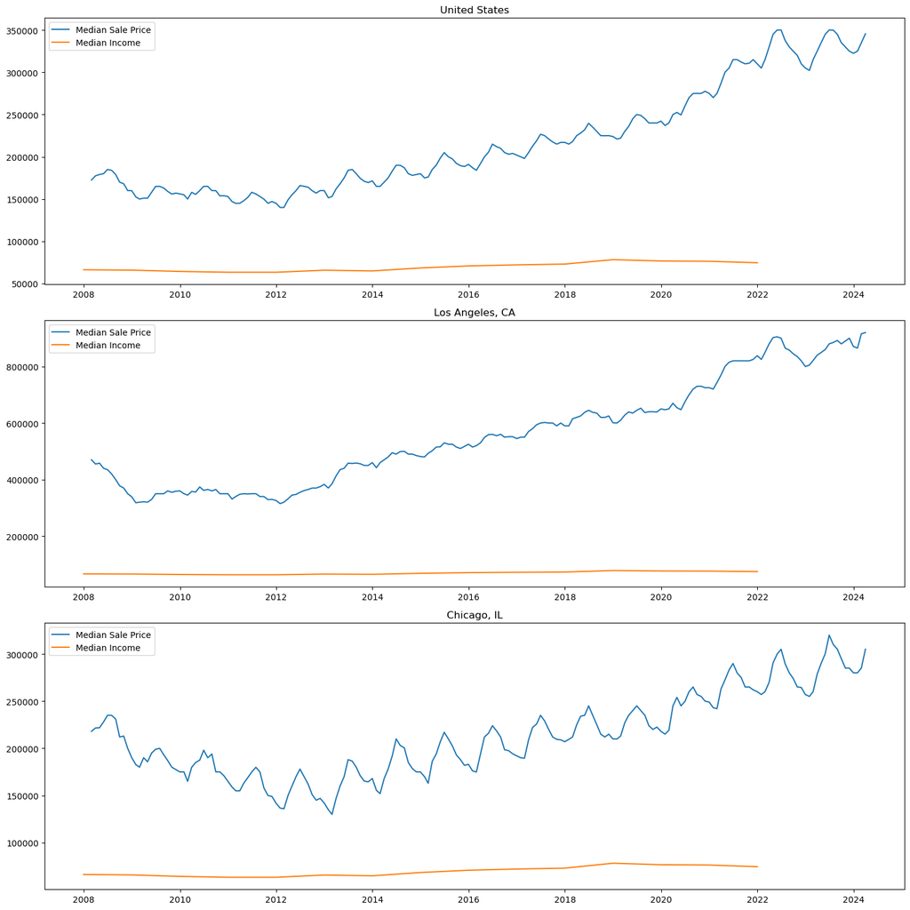

```python
# setting up plot variables
nrows = 3
ncols = 1
total_plots = nrows * ncols
fig, axes = plt.subplots(nrows=nrows, ncols=ncols, figsize=(15, 15))

# creating x_values for dataframe and income
# using normalized_median_df to show we are plotting normalized data in code better, could be median_df though they are the same at this point
x_values = normalized_median_df.index
income_x_values = normalized_income_df.index

# plot the values on the subplot grid
for i, col in enumerate(normalized_median_df.columns[:total_plots]):
    # set axes index
    if nrows == 1 or ncols == 1:
        ax = axes[i]
    else:
        ax = axes[i // ncols, i % ncols]

    # plot median data for the current location
    ax.plot(x_values, normalized_median_df[col], label='Median Sale Price')

    #plot corresponding income data for the current location
    ax.plot(income_x_values, normalized_income_df["Income"].values, label='Median Income')

    ax.set_title(col)
    ax.legend()

plt.tight_layout()
plt.show()
```

## Data Analysis

Next we can start creating synthetic data values that will work better with something like linear regression and give a better idea of the trends of the data. These plots here show the smoothing of the median sale price by decomposing the data and removing any seasonal factors. You can see the jumpiness of the plot caused by the data, this can be factored in to our analysis, but separating the data will become useful.

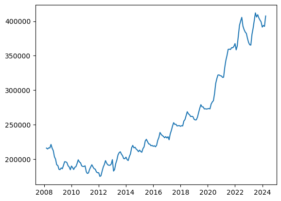

```python
median_df["Average"] = mean_df.mean(axis=1)
plt.plot(median_df["Average"])
```

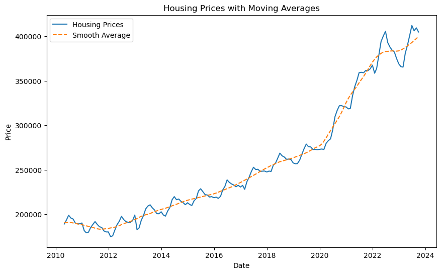

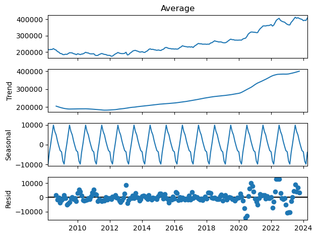

```python
# feature extraction for predictions



# getting year month and quarter
median_df['Year'] = median_df.index.year
median_df['Month'] = median_df.index.month
median_df['Quarter'] = median_df.index.quarter

# using seasonal decompose to find the trend in the data (smooth average basically)
result = seasonal_decompose(median_df['Average'], model='additive', period=12)
median_df['SMA'] = result.trend
median_df['Seasonal'] = result.seasonal
median_df['SSDA'] = median_df['Average'].rolling(window=12).std()
# create lag points from previous data for prediction
median_df['Lag10'] = median_df['SMA'].shift(10)
median_df['Lag20'] = median_df['SMA'].shift(20)

# removing any unused columns
median_df.dropna(inplace=True)

# plotting the data of smooth trend and extra data from the seasonal decompose
plt.figure(figsize=(10, 6))
plt.plot(median_df['Average'], label='Housing Prices')
plt.plot(median_df['SMA'], label='Smooth Average', linestyle='--')
plt.title('Housing Prices with Moving Averages')
plt.xlabel('Date')
plt.ylabel('Price')
plt.legend()
plt.show()

result.plot()
plt.show()
```

## Feature Data

Once the feature data has been extracted, we can quickly plot the values and visualize what each value is and how it might affect the linear regression.

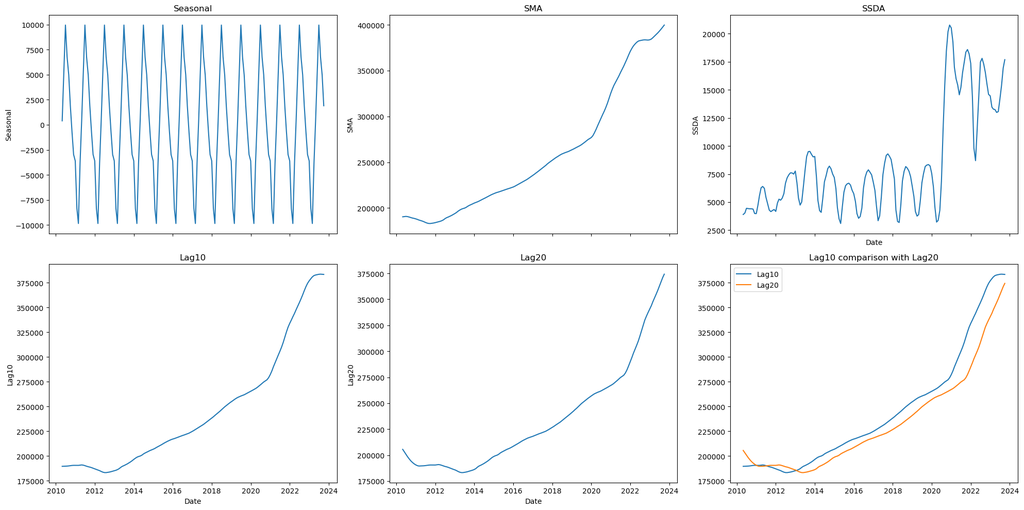

```python
# list of features to plot
features = ['Seasonal', 'SMA', 'SSDA', 'Lag10', 'Lag20']

nrows = 2
ncols = 3

# setting up subplot
fig, axes = plt.subplots(nrows=nrows, ncols=ncols, figsize=(20, 10), sharex=True)
axes = axes.flatten()

# creating a plot for each feature
for i, feature in enumerate(features):
    axes[i].plot(median_df.index, median_df[feature])
    axes[i].set_title(feature)
    axes[i].set_ylabel(feature)
    if i >= len(features) - ncols:
        axes[i].set_xlabel('Date')

# last plot with both lag10 and lag20 for comparison
axes[5].plot(median_df.index, median_df['Lag10'], label='Lag10')
axes[5].plot(median_df.index, median_df['Lag20'], label='Lag20')
axes[5].set_title("Lag10 comparison with Lag20")
axes[5].legend()

plt.tight_layout()
plt.show()
```

## Predicting Future Outcomes

Now we can start working towards building a model using the data that can predict future outcomes. This will be beneficial for the future when housing prices for future dates can be looked at. Using the features extracted from the dataset, we can train a model using the LinearRegression class. The data is split by year and the outputs of the prediction can be shown below. As you can see, the model is fairly accurate and accounting for seasonal trends.

```
RMSE: 6280.5587762192345
```

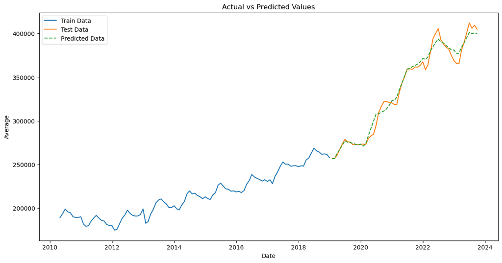

```python
# setting up training and testing data
train_data = median_df[median_df['Year'] <= 2018]
test_data = median_df[median_df['Year'] > 2018]

# selecting certain feature columns and for both the testing and training data
features = ['Year', 'Month', 'Quarter', 'Seasonal', 'SMA', 'SSDA', 'Lag10', 'Lag20']
X_train = train_data[features]
y_train = train_data['Average']
X_test = test_data[features]
y_test = test_data['Average']

# linear regression model
model = LinearRegression()
# training model on training data
model.fit(X_train, y_train)

# creating predictions on test data
y_pred = model.predict(X_test)

# finding the mean squared error between the y-test and prediction
mse = mean_squared_error(y_test, y_pred)
rmse = np.sqrt(mse)
print(f'RMSE: {rmse}')

# plotting data
plt.figure(figsize=(14, 7))
plt.plot(train_data.index, train_data['Average'], label='Train Data')
plt.plot(test_data.index, y_test, label='Test Data')
plt.plot(test_data.index, y_pred, label='Predicted Data', linestyle='--')
plt.legend()
plt.xlabel('Date')
plt.ylabel('Average')
plt.title('Actual vs Predicted Values')
plt.show()
```

## A Quick Look At Location Specific Data

These values are going to be similar, so the data computed using the average of all locations is generalizable. But this is a factor that was left out as the mean of the locations would provide a good comparison. With this in mind, there were a few locations that were significantly higher or lower compared to the rest. The bar graph below represents the difference in rate of change of the income and housing data by location. This is represented in decimal form, so the range of the data is almost 3.5%. Again this is caused by outliers in the data, so the factor that is has can be mostly ignored as this is a more general analysis of the data, but it is interesting to see the differences.

```
Location with the minimum difference in average rate of change: Little Rock, AR, Difference: 0.001475024815670341
Location with the maximum difference in average rate of change: Decatur, IL, Difference: 0.03672927309294914
The range of the data between the minimum and maximum average rate of change: 0.0352542482772788
```

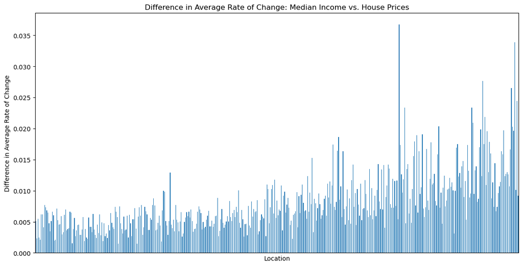

```python
# sampling data to create monthly values for income
income_df_monthly = income_df.resample('M').ffill()

# calculate the monthly rate of change for income
income_df_monthly['ROC'] = income_df_monthly['Income'].pct_change()

# calculate the monthly rate of change for the different locations
location_columns = [col for col in median_df.columns if ',' in col]
rate_change_df = median_df[location_columns].pct_change()

# restrict the end dates for both dataframes
end_date = '2022-12-31'
rate_change_df = rate_change_df.loc[:end_date]
income_df_monthly = income_df_monthly.loc[:end_date]

# make sure that the data values both cover the same timespan
common_dates = rate_change_df.index.intersection(income_df_monthly.index)
rate_change_df = rate_change_df.loc[common_dates]
income_df_monthly = income_df_monthly.loc[common_dates]

# create average income rate of change for the different locations
avg_income_rate_change = income_df_monthly['ROC'].mean()
avg_house_price_rate_change = rate_change_df.mean()

# find the difference between the average rate of change in income and house prices
diff_avg_rate_change = avg_house_price_rate_change - avg_income_rate_change

# get indices of both max differences in income and housing rate of change
max_diff_location = diff_avg_rate_change.idxmax()
max_diff_value = diff_avg_rate_change.max()

# get indices of both min differences in income and housing rate of change
min_diff_location = diff_avg_rate_change.idxmin()
min_diff_value = diff_avg_rate_change.min()

print(f"Location with the minimum difference in average rate of change: {min_diff_location}, Difference: {min_diff_value}")
print(f"Location with the maximum difference in average rate of change: {max_diff_location}, Difference: {max_diff_value}")
print(f"The range of the data between the minimum and maximum average rate of change: {max_diff_value - min_diff_value}")

# average rate of change differences as a bar plot
plt.figure(figsize=(14, 7))
diff_avg_rate_change.plot(kind='bar')
plt.xlabel('Location')
plt.ylabel('Difference in Average Rate of Change')
plt.title('Difference in Average Rate of Change: Median Income vs. House Prices')
plt.xticks([])
plt.show()
```

## Conclusion

This notebook provided a comprehensive analysis of housing data, focusing on the relationship between median income and average housing prices. By examining various factors such as inflation and regional disparities, we highlighted the significant differences in the rate of change between income and house prices. Our findings reveal that certain locations experience more pronounced discrepancies, which can inform policymakers and stakeholders in addressing housing affordability challenges. The visualization and statistical methods employed here offer a clear picture of the current housing market dynamics, aiding in future decision-making processes.